# **AI CA5 Phase2 Report**

## Atieh Armin - 810197648

The goal of this project is to get familiar with Keras library and implement a neural network that identifies COVID19 or PNEUMONIA using Keras.

### **Preprocessing**

First, the train data and the test data are read using *flow_from_directory* function. The target size of the images are set to (80,80), the color mode is set to grayscale and the batch size is 32.

```python
from google.colab import drive
drive.mount('/content/drive')
```

```python
!cp "/content/drive/MyDrive/xray.zip" .
!unzip xray.zip
```

[output not shown]

[output cut: 4946 more lines]

[output not shown]

```python
from tensorflow.keras import *
import matplotlib.pyplot as plt
import matplotlib.image as mpimg
import numpy as np
from sklearn.metrics import classification_report

def get_labels(loader):
  labels = []
  for i in range(len(loader)):
    x_batch,y_batch = loader.next()
    for label in y_batch:
      labels.append(backend.argmax(label))
  return np.array(labels)

def print_details(history,train_data,test_data):
  predictions = ANN.predict(train_data)
  labels = get_labels(train_data)
  classification_report(labels,backend.argmax(predictions).numpy())

  predictions = ANN.predict(test_data)
  labels = get_labels(test_data)
  classification_report(labels,backend.argmax(predictions).numpy())

  plt.plot(history.history['loss'])
  plt.plot(history.history['val_loss'])
  plt.title('Model Loss')
  plt.ylabel('Loss')
  plt.xlabel('Epoch')
  plt.legend(['train','test'], loc='upper left')
  plt.show()

def data_reset(scale):
  dataLoader = preprocessing.image.ImageDataGenerator(rescale=scale)
  train_data = dataLoader.flow_from_directory("/content/Data/train",
                                             target_size = (80,80),
                                             color_mode = "grayscale",
                                             batch_size = 32)
  test_data = dataLoader.flow_from_directory("/content/Data/test",
                                             target_size = (80,80),
                                             color_mode = "grayscale",
                                             batch_size = 32)
  return train_data,test_data
```

```python
dataLoader = preprocessing.image.ImageDataGenerator()
train_data = dataLoader.flow_from_directory("/content/Data/train",
                                             target_size = (80,80),
                                             color_mode = "grayscale",
                                             batch_size = 32)
```

```
Found 5144 images belonging to 3 classes.
```

```python
test_data = dataLoader.flow_from_directory("/content/Data/test",
                                             target_size = (80,80),
                                             color_mode = "grayscale",
                                             batch_size = 32)
```

```
Found 1288 images belonging to 3 classes.
```

Here is a sample of each class:COVID19, NORMAL and PNEUMONIA.

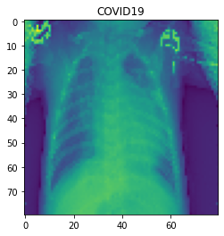

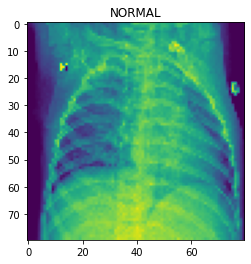

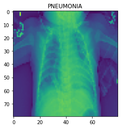

```python
i=0
for cl in (train_data.class_indices):
  img = preprocessing.image.img_to_array(train_data[i][0][0])
  plt.imshow(img.reshape(80,80))
  plt.title(cl)
  plt.show()
  i+=1
```

The class distribution among train data is shown below.

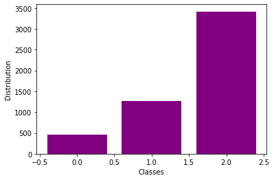

```python
N_CLASSES = 3
count = []
for i in range(N_CLASSES):
  count.append(np.sum(train_data.classes == i))

x = list(range(N_CLASSES))
plt.bar(x, count, color="purple")
plt.xlabel("Classes")
plt.ylabel("Distribution")
plt.show()
```

### **Implementing Neural Network**

A neural network with two hidden layers is implemented with the parameters shown below:

1. Activation function of hidden layers = Relu
2. Activation function of output layer = Softmax
3. Number of the neurons of the hidden layers = 1024
4. Batch size = 32
5. Epochs = 10
6. Loss function = Crossentropy

```python
inp = layers.Input(shape=(80,80,1))
first_layer = layers.Flatten()(inp)
second_layer = layers.Dense(1024,activation="relu")(first_layer)
third_layer = layers.Dense(1024,activation="relu")(second_layer)
output_layer = layers.Dense(3,activation="softmax")(third_layer)
ANN = models.Model(inputs = inp,outputs = output_layer)
ANN.compile(optimizer=optimizers.SGD(learning_rate=0.01),loss="categorical_crossentropy",metrics=["accuracy"])
```

The summary of the network is shown below.

```python
ANN.summary()
```

```
Model: "model_12"
_________________________________________________________________
Layer (type)                 Output Shape              Param #
=================================================================
input_13 (InputLayer)        [(None, 80, 80, 1)]       0
_________________________________________________________________
flatten_12 (Flatten)         (None, 6400)              0
_________________________________________________________________
dense_44 (Dense)             (None, 1024)              6554624
_________________________________________________________________
dense_45 (Dense)             (None, 1024)              1049600
_________________________________________________________________
dense_46 (Dense)             (None, 3)                 3075
=================================================================
Total params: 7,607,299
Trainable params: 7,607,299
Non-trainable params: 0
_________________________________________________________________
```

As you can see, the loss values is *nan*. It seems that the network overflowed. Details of this network is shown bellow.

```python
 history = ANN.fit(train_data,validation_data=test_data,epochs=10)
```

```
Found 5144 images belonging to 3 classes.
Found 1288 images belonging to 3 classes.
```

```
              precision    recall  f1-score   support

           0       0.09      1.00      0.16       460
           1       0.00      0.00      0.00      1266
           2       0.00      0.00      0.00      3418

    accuracy                           0.09      5144
   macro avg       0.03      0.33      0.05      5144
weighted avg       0.01      0.09      0.01      5144

              precision    recall  f1-score   support

           0       0.09      1.00      0.17       116
           1       0.00      0.00      0.00       317
           2       0.00      0.00      0.00       855

    accuracy                           0.09      1288
   macro avg       0.03      0.33      0.06      1288
weighted avg       0.01      0.09      0.01      1288
```

[figure not shown]

```python
train_data, test_data = data_reset(None)
labels = get_labels(train_data)
predictions = ANN.predict(train_data)
print(classification_report(labels,backend.argmax(predictions).numpy()))

labels = get_labels(test_data)
predictions = ANN.predict(test_data)
print(classification_report(labels,backend.argmax(predictions).numpy()))

print_details(history,train_data,test_data)
```

Now lets see another neural network which the activation function of its hidden layer is Tanh. As shown bellow the loss value is not *nan* anymore and the accuracy is better. This happend becaues tanh automatically returns an output in range (-1,1). Thus, weights and outputs of the layer is in a range and the network won't overflow. The general solution for this problem is to normalize numbers before get them as inputs. This is done in the next section by dividing numbers by 255.

```python
train_data, test_data = data_reset(None)

inp = layers.Input(shape=(80,80,1))
first_layer = layers.Flatten()(inp)
second_layer = layers.Dense(1024,activation="tanh")(first_layer)
third_layer = layers.Dense(1024,activation="tanh")(second_layer)
output_layer = layers.Dense(3,activation="softmax")(third_layer)
ANN = models.Model(inputs = inp,outputs = output_layer)
ANN.compile(optimizer=optimizers.SGD(learning_rate=0.01),loss="categorical_crossentropy",metrics=["accuracy"])
```

```
Found 5144 images belonging to 3 classes.
Found 1288 images belonging to 3 classes.
```

```python
 history = ANN.fit(train_data,validation_data=test_data,epochs=10)
```

```
Found 5144 images belonging to 3 classes.
Found 1288 images belonging to 3 classes.
```

```
              precision    recall  f1-score   support

           0       0.00      0.00      0.00       460
           1       0.00      0.00      0.00      1266
           2       0.66      1.00      0.80      3418

    accuracy                           0.66      5144
   macro avg       0.22      0.33      0.27      5144
weighted avg       0.44      0.66      0.53      5144

              precision    recall  f1-score   support

           0       0.00      0.00      0.00       116
           1       0.00      0.00      0.00       317
           2       0.66      1.00      0.80       855

    accuracy                           0.66      1288
   macro avg       0.22      0.33      0.27      1288
weighted avg       0.44      0.66      0.53      1288
```

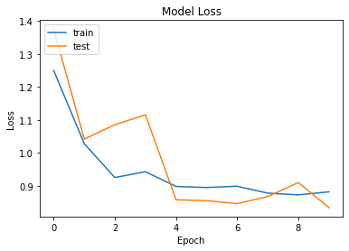

```python
train_data, test_data = data_reset(1/255.)
labels = get_labels(train_data)
predictions = ANN.predict(train_data)
print(classification_report(labels,backend.argmax(predictions).numpy()))

labels = get_labels(test_data)
predictions = ANN.predict(test_data)
print(classification_report(labels,backend.argmax(predictions).numpy()))

print_details(history,train_data,test_data)
```

Here is a new neural network with normalized input data and relu activation function for hidden layers.

```python
train_data, test_data = data_reset(1/255.)

inp = layers.Input(shape=(80,80,1))
first_layer = layers.Flatten()(inp)
second_layer = layers.Dense(1024,activation="relu")(first_layer)
third_layer = layers.Dense(1024,activation="relu")(second_layer)
output_layer = layers.Dense(3,activation="softmax")(third_layer)
ANN = models.Model(inputs = inp,outputs = output_layer)
ANN.compile(optimizer=optimizers.SGD(learning_rate=0.01),loss="categorical_crossentropy",metrics=["accuracy"])

history = ANN.fit(train_data,validation_data=test_data,epochs=10)
```

```
Found 5144 images belonging to 3 classes.
Found 1288 images belonging to 3 classes.
```

```
Found 5144 images belonging to 3 classes.
Found 1288 images belonging to 3 classes.
              precision    recall  f1-score   support

           0       0.88      0.89      0.89       460
           1       0.67      0.97      0.80      1266
           2       0.98      0.82      0.89      3418

    accuracy                           0.86      5144
   macro avg       0.85      0.90      0.86      5144
weighted avg       0.90      0.86      0.87      5144

              precision    recall  f1-score   support

           0       0.85      0.91      0.88       116
           1       0.73      0.97      0.83       317
           2       0.99      0.86      0.92       855

    accuracy                           0.89      1288
   macro avg       0.86      0.91      0.88      1288
weighted avg       0.91      0.89      0.89      1288
```

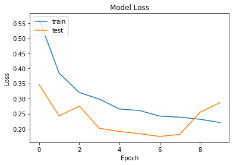

```python
train_data, test_data = data_reset(1/255.)

labels = get_labels(train_data)
predictions = ANN.predict(train_data)
print(classification_report(labels,backend.argmax(predictions).numpy()))

labels = get_labels(test_data)
predictions = ANN.predict(test_data)
print(classification_report(labels,backend.argmax(predictions).numpy()))

print_details(history,train_data,test_data)
```

Here is the implementation of a nerual network with highest f1-score.

```python
train_data, test_data = data_reset(1/255.)

inp = layers.Input(shape=(80,80,1))
first_layer = layers.Flatten()(inp)
second_layer = layers.Dense(4096,activation="relu")(first_layer)
third_layer = layers.Dense(2048,activation="relu")(second_layer)
fourth_layer = layers.Dense(1024,activation="relu")(third_layer)
output_layer = layers.Dense(3,activation="softmax")(fourth_layer)

ANN = models.Model(inputs = inp,outputs = output_layer)
ANN.compile(optimizer=optimizers.SGD(learning_rate=0.01),loss="categorical_crossentropy",metrics=["accuracy"])

history = ANN.fit(train_data,validation_data=test_data,epochs=10)
```

```
Found 5144 images belonging to 3 classes.
Found 1288 images belonging to 3 classes.
```

```
Found 5144 images belonging to 3 classes.
Found 1288 images belonging to 3 classes.
              precision    recall  f1-score   support

           0       0.96      0.85      0.90       460
           1       0.95      0.79      0.86      1266
           2       0.91      0.99      0.95      3418

    accuracy                           0.92      5144
   macro avg       0.94      0.87      0.90      5144
weighted avg       0.93      0.92      0.92      5144

              precision    recall  f1-score   support

           0       1.00      0.82      0.90       116
           1       0.94      0.83      0.88       317
           2       0.92      0.98      0.95       855

    accuracy                           0.93      1288
   macro avg       0.95      0.88      0.91      1288
weighted avg       0.93      0.93      0.93      1288
```

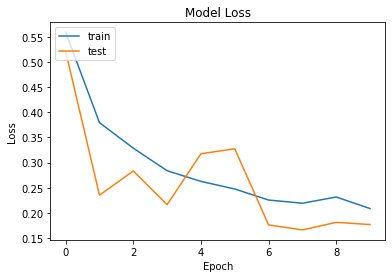

```python
train_data, test_data = data_reset(1/255.)

labels = get_labels(train_data)
predictions = ANN.predict(train_data)
print(classification_report(labels,backend.argmax(predictions).numpy()))

labels = get_labels(test_data)
predictions = ANN.predict(test_data)
print(classification_report(labels,backend.argmax(predictions).numpy()))

print_details(history,train_data,test_data)
```

## **Optimizers**

### SGD with Momentum

A major disadvantage of the Mini Batch SGD algorithm is that updates of weight are very noisy. SGD with momentum overcomes this disadvantage by denoising the gradients. Updates of weight are dependent on noisy derivative and if we somehow denoise the derivatives then converging time will decrease. The idea is to denoise derivative using exponential weighting average that is to give more weightage to recent updates compared to the previous update. Momentum at time ‘t’ is computed using all previous updates giving more weightage to recent updates compared to the previous update. This lead to speed up the convergence. Momentum has 2 advantages which makes it a better choice than SGD:

1. Reduces the oscillations and high variance of the parameters.
2. Converges faster than gradient descent.

Here is the implementation of the last neural network with different momentum:

1) Mumentum = 0.5

```python
train_data, test_data = data_reset(1/255.)

inp = layers.Input(shape=(80,80,1))
first_layer = layers.Flatten()(inp)
second_layer = layers.Dense(4096,activation="relu")(first_layer)
third_layer = layers.Dense(2048,activation="relu")(second_layer)
fourth_layer = layers.Dense(1024,activation="relu")(third_layer)
output_layer = layers.Dense(3,activation="softmax")(fourth_layer)

ANN = models.Model(inputs = inp,outputs = output_layer)

ANN.compile(optimizer=optimizers.SGD(learning_rate=0.01,momentum=0.5) ,loss="categorical_crossentropy",metrics=["accuracy"])

history = ANN.fit(train_data,validation_data=test_data,epochs=10)
```

```
Found 5144 images belonging to 3 classes.
Found 1288 images belonging to 3 classes.
```

```
Found 5144 images belonging to 3 classes.
Found 1288 images belonging to 3 classes.
              precision    recall  f1-score   support

           0       0.94      0.93      0.94       460
           1       0.92      0.89      0.91      1266
           2       0.96      0.97      0.96      3418

    accuracy                           0.95      5144
   macro avg       0.94      0.93      0.94      5144
weighted avg       0.95      0.95      0.95      5144

              precision    recall  f1-score   support

           0       0.93      0.94      0.94       116
           1       0.92      0.90      0.91       317
           2       0.96      0.97      0.97       855

    accuracy                           0.95      1288
   macro avg       0.94      0.94      0.94      1288
weighted avg       0.95      0.95      0.95      1288
```

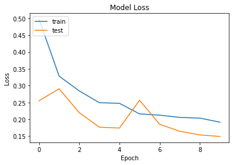

```python
train_data, test_data = data_reset(1/255.)

labels = get_labels(train_data)
predictions = ANN.predict(train_data)
print(classification_report(labels,backend.argmax(predictions).numpy()))

labels = get_labels(test_data)
predictions = ANN.predict(test_data)
print(classification_report(labels,backend.argmax(predictions).numpy()))

print_details(history,train_data,test_data)
```

2)Mumentum = 0.9

```python
train_data, test_data = data_reset(1/255.)

inp = layers.Input(shape=(80,80,1))
first_layer = layers.Flatten()(inp)
second_layer = layers.Dense(4096,activation="relu")(first_layer)
third_layer = layers.Dense(2048,activation="relu")(second_layer)
fourth_layer = layers.Dense(1024,activation="relu")(third_layer)
output_layer = layers.Dense(3,activation="softmax")(fourth_layer)

ANN = models.Model(inputs = inp,outputs = output_layer)

ANN.compile(optimizer=optimizers.SGD(learning_rate=0.01,momentum=0.9) ,loss="categorical_crossentropy",metrics=["accuracy"])

history = ANN.fit(train_data,validation_data=test_data,epochs=10)
```

```
Found 5144 images belonging to 3 classes.
Found 1288 images belonging to 3 classes.
```

```
Found 5144 images belonging to 3 classes.
Found 1288 images belonging to 3 classes.
              precision    recall  f1-score   support

           0       0.94      0.87      0.90       460
           1       0.92      0.87      0.89      1266
           2       0.94      0.97      0.96      3418

    accuracy                           0.94      5144
   macro avg       0.93      0.90      0.92      5144
weighted avg       0.93      0.94      0.93      5144

              precision    recall  f1-score   support

           0       0.98      0.87      0.92       116
           1       0.93      0.91      0.92       317
           2       0.95      0.97      0.96       855

    accuracy                           0.95      1288
   macro avg       0.95      0.92      0.93      1288
weighted avg       0.95      0.95      0.95      1288
```

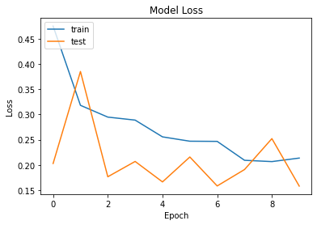

```python
train_data, test_data = data_reset(1/255.)

labels = get_labels(train_data)
predictions = ANN.predict(train_data)
print(classification_report(labels,backend.argmax(predictions).numpy()))

labels = get_labels(test_data)
predictions = ANN.predict(test_data)
print(classification_report(labels,backend.argmax(predictions).numpy()))

print_details(history,train_data,test_data)
```

3) Mumentum = 0.99: As you can see below, with this momentum it seems that the loss is raising because 0.99 is too much and it makes our network change faster.

```python
train_data, test_data = data_reset(1/255.)

inp = layers.Input(shape=(80,80,1))
first_layer = layers.Flatten()(inp)
second_layer = layers.Dense(4096,activation="relu")(first_layer)
third_layer = layers.Dense(2048,activation="relu")(second_layer)
fourth_layer = layers.Dense(1024,activation="relu")(third_layer)
output_layer = layers.Dense(3,activation="softmax")(fourth_layer)

ANN = models.Model(inputs = inp,outputs = output_layer)

ANN.compile(optimizer=optimizers.SGD(learning_rate=0.01,momentum=0.99) ,loss="categorical_crossentropy",metrics=["accuracy"])

history = ANN.fit(train_data,validation_data=test_data,epochs=10)
```

```
Found 5144 images belonging to 3 classes.
Found 1288 images belonging to 3 classes.
```

```
Found 5144 images belonging to 3 classes.
Found 1288 images belonging to 3 classes.
```

```
              precision    recall  f1-score   support

           0       0.00      0.00      0.00       460
           1       0.00      0.00      0.00      1266
           2       0.66      1.00      0.80      3418

    accuracy                           0.66      5144
   macro avg       0.22      0.33      0.27      5144
weighted avg       0.44      0.66      0.53      5144

              precision    recall  f1-score   support

           0       0.00      0.00      0.00       116
           1       0.00      0.00      0.00       317
           2       0.66      1.00      0.80       855

    accuracy                           0.66      1288
   macro avg       0.22      0.33      0.27      1288
weighted avg       0.44      0.66      0.53      1288
```

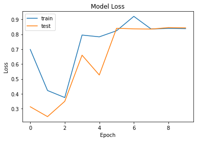

```python
train_data, test_data = data_reset(1/255.)
labels = get_labels(train_data)
predictions = ANN.predict(train_data)
print(classification_report(labels,backend.argmax(predictions).numpy()))

labels = get_labels(test_data)
predictions = ANN.predict(test_data)
print(classification_report(labels,backend.argmax(predictions).numpy()))

print_details(history,train_data,test_data)
```

### Adam

Adam (Adaptive Moment Estimation) works with momentums of first and second order. The intuition behind the Adam is that we don’t want to roll so fast just because we can jump over the minimum, we want to decrease the velocity a little bit for a careful search.

```python
train_data, test_data = data_reset(1/255.)

inp = layers.Input(shape=(80,80,1))
first_layer = layers.Flatten()(inp)
second_layer = layers.Dense(4096,activation="relu")(first_layer)
third_layer = layers.Dense(2048,activation="relu")(second_layer)
fourth_layer = layers.Dense(1024,activation="relu")(third_layer)
output_layer = layers.Dense(3,activation="softmax")(fourth_layer)

ANN = models.Model(inputs = inp,outputs = output_layer)

ANN.compile(optimizer=optimizers.Adam(learning_rate=0.001) ,loss="categorical_crossentropy",metrics=["accuracy"])

history = ANN.fit(train_data,validation_data=test_data,epochs=10)
```

```
Found 5144 images belonging to 3 classes.
Found 1288 images belonging to 3 classes.
```

```
Found 5144 images belonging to 3 classes.
Found 1288 images belonging to 3 classes.
              precision    recall  f1-score   support

           0       0.93      0.94      0.93       460
           1       0.96      0.76      0.85      1266
           2       0.91      0.98      0.95      3418

    accuracy                           0.93      5144
   macro avg       0.94      0.89      0.91      5144
weighted avg       0.93      0.93      0.92      5144

              precision    recall  f1-score   support

           0       0.93      0.93      0.93       116
           1       0.95      0.83      0.89       317
           2       0.94      0.98      0.96       855

    accuracy                           0.94      1288
   macro avg       0.94      0.91      0.93      1288
weighted avg       0.94      0.94      0.94      1288
```

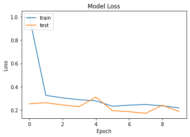

```python
train_data, test_data = data_reset(1/255.)

labels = get_labels(train_data)
predictions = ANN.predict(train_data)
print(classification_report(labels,backend.argmax(predictions).numpy()))

labels = get_labels(test_data)
predictions = ANN.predict(test_data)
print(classification_report(labels,backend.argmax(predictions).numpy()))

print_details(history,train_data,test_data)
```

## **Epochs**

We are using a limited dataset and to optimise the learning and the graph we are using Adam. So, updating the weights with single pass or one epoch is not enough. As the number of epochs increases, more number of times the weight are changed in the neural network and the curve goes from underfitting to optimal to overfitting curve.

Lets train the neural network for 20 epochs.

```python
train_data, test_data = data_reset(1/255.)

inp = layers.Input(shape=(80,80,1))
first_layer = layers.Flatten()(inp)
second_layer = layers.Dense(4096,activation="relu")(first_layer)
third_layer = layers.Dense(2048,activation="relu")(second_layer)
fourth_layer = layers.Dense(1024,activation="relu")(third_layer)
output_layer = layers.Dense(3,activation="softmax")(fourth_layer)

ANN = models.Model(inputs = inp,outputs = output_layer)

ANN.compile(optimizer=optimizers.Adam(learning_rate=0.001) ,loss="categorical_crossentropy",metrics=["accuracy"])

history = ANN.fit(train_data,validation_data=test_data,epochs=20)
```

```
Found 5144 images belonging to 3 classes.
Found 1288 images belonging to 3 classes.
```

```
Found 5144 images belonging to 3 classes.
Found 1288 images belonging to 3 classes.
              precision    recall  f1-score   support

           0       0.88      0.95      0.91       460
           1       0.92      0.92      0.92      1266
           2       0.97      0.96      0.96      3418

    accuracy                           0.95      5144
   macro avg       0.92      0.94      0.93      5144
weighted avg       0.95      0.95      0.95      5144

              precision    recall  f1-score   support

           0       0.87      0.90      0.88       116
           1       0.89      0.94      0.91       317
           2       0.97      0.95      0.96       855

    accuracy                           0.94      1288
   macro avg       0.91      0.93      0.92      1288
weighted avg       0.94      0.94      0.94      1288
```

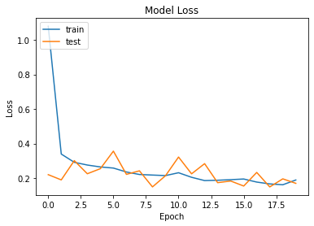

```python
train_data, test_data = data_reset(1/255.)

labels = get_labels(train_data)
predictions = ANN.predict(train_data)
print(classification_report(labels,backend.argmax(predictions).numpy()))

labels = get_labels(test_data)
predictions = ANN.predict(test_data)
print(classification_report(labels,backend.argmax(predictions).numpy()))

print_details(history,train_data,test_data)
```

## **Loss Functions**

You saw the results of neural networks with CrossEntropy Loss function before.

Here is the neural network with MSE loss function. MSE does not give good result for classifications. There are two reasons why Mean Squared Error(MSE) is a bad choice for binary classification problems:

- First, using MSE means that we assume that the underlying data has been generated from a normal distribution (a bell-shaped curve). In Bayesian terms this means we assume a Gaussian prior. While in reality, a dataset that can be classified into two categories (i.e binary) is not from a normal distribution but a Bernoulli distribution. If we use maximum likelihood estimation(MLE), assuming that the data is from a normal distribution(a wrong assumption, by the way), we get the MSE as a Cost function for optimizing our model.
- Secondly, the MSE function is non-convex for binary classification. In simple terms, if a binary classification model is trained with MSE Cost function, it is not guaranteed to minimize the Cost function. This is because MSE function expects real-valued inputs in range(-∞, ∞), while binary classification models output probabilities in range(0,1) through the sigmoid/logistic function.

```python
train_data, test_data = data_reset(1/255.)

inp = layers.Input(shape=(80,80,1))
first_layer = layers.Flatten()(inp)
second_layer = layers.Dense(4096,activation="relu")(first_layer)
third_layer = layers.Dense(2048,activation="relu")(second_layer)
fourth_layer = layers.Dense(1024,activation="relu")(third_layer)
output_layer = layers.Dense(3,activation="softmax")(fourth_layer)

ANN = models.Model(inputs = inp,outputs = output_layer)

ANN.compile(optimizer=optimizers.Adam(learning_rate=0.001) ,loss="mse",metrics=["accuracy"])

history = ANN.fit(train_data,validation_data=test_data,epochs=20)
```

```
Found 5144 images belonging to 3 classes.
Found 1288 images belonging to 3 classes.
```

```
Found 5144 images belonging to 3 classes.
Found 1288 images belonging to 3 classes.
```

```
              precision    recall  f1-score   support

           0       0.00      0.00      0.00       460
           1       0.00      0.00      0.00      1266
           2       0.66      1.00      0.80      3418

    accuracy                           0.66      5144
   macro avg       0.22      0.33      0.27      5144
weighted avg       0.44      0.66      0.53      5144

              precision    recall  f1-score   support

           0       0.00      0.00      0.00       116
           1       0.00      0.00      0.00       317
           2       0.66      1.00      0.80       855

    accuracy                           0.66      1288
   macro avg       0.22      0.33      0.27      1288
weighted avg       0.44      0.66      0.53      1288
```

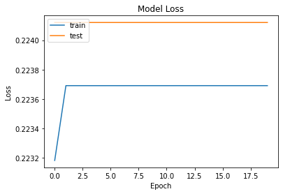

```python
train_data, test_data = data_reset(1/255.)

labels = get_labels(train_data)
predictions = ANN.predict(train_data)
print(classification_report(labels,backend.argmax(predictions).numpy()))

labels = get_labels(test_data)
predictions = ANN.predict(test_data)
print(classification_report(labels,backend.argmax(predictions).numpy()))

print_details(history,train_data,test_data)
```

## **Regularization**

This technique discourages learning a more complex or flexible model, so as to avoid the risk of overfitting. There are mainly two types of regularization techniques:

- L1 regularization or LASSO regression.
- L2 regularization or Ridge regression.

```python
train_data, test_data = data_reset(1/255.)

inp = layers.Input(shape=(80,80,1))
first_layer = layers.Flatten()(inp)
second_layer = layers.Dense(4096,activation="relu",kernel_regularizer=regularizers.l2(0.0001))(first_layer)
third_layer = layers.Dense(2048,activation="relu",kernel_regularizer=regularizers.l2(0.0001))(second_layer)
fourth_layer = layers.Dense(1024,activation="relu",kernel_regularizer=regularizers.l2(0.0001))(third_layer)
output_layer = layers.Dense(3,activation="softmax",kernel_regularizer=regularizers.l2(0.0001))(fourth_layer)

ANN = models.Model(inputs = inp,outputs = output_layer)
ANN.compile(optimizer=optimizers.SGD(learning_rate=0.1),loss="categorical_crossentropy",metrics=["accuracy"])

history = ANN.fit(train_data,validation_data=test_data,epochs=20)
```

```
Found 5144 images belonging to 3 classes.
Found 1288 images belonging to 3 classes.
```

```
Found 5144 images belonging to 3 classes.
Found 1288 images belonging to 3 classes.
              precision    recall  f1-score   support

           0       0.95      0.86      0.90       460
           1       0.90      0.82      0.86      1266
           2       0.93      0.97      0.95      3418

    accuracy                           0.92      5144
   macro avg       0.93      0.89      0.90      5144
weighted avg       0.92      0.92      0.92      5144

              precision    recall  f1-score   support

           0       0.98      0.85      0.91       116
           1       0.91      0.86      0.88       317
           2       0.94      0.98      0.96       855

    accuracy                           0.94      1288
   macro avg       0.94      0.90      0.92      1288
weighted avg       0.94      0.94      0.94      1288
```

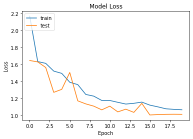

```python
train_data, test_data = data_reset(1/255.)

labels = get_labels(train_data)
predictions = ANN.predict(train_data)
print(classification_report(labels,backend.argmax(predictions).numpy()))

labels = get_labels(test_data)
predictions = ANN.predict(test_data)
print(classification_report(labels,backend.argmax(predictions).numpy()))

print_details(history,train_data,test_data)
```

Dropout technique works by randomly reducing the number of interconnecting neurons within a neural network. At every training step, each neuron has a chance of being left out, or rather, dropped out of the collated contribution from connected neurons. This technique minimizes overfitting because each neuron becomes independently sufficient, in the sense that the neurons within the layers learn weight values that are not based on the cooperation of its neighbouring neurons. Here is the implementation of the network with dropout for every layer.

```python
train_data, test_data = data_reset(1/255.)


inp = layers.Input(shape=(80,80,1))
first_layer = layers.Flatten()(inp)
first_layer = layers.Dropout(0.1)(first_layer)
second_layer = layers.Dense(4096,activation="relu",kernel_regularizer=regularizers.l2(0.0001))(first_layer)
second_layer = layers.Dropout(0.1)(second_layer)
third_layer = layers.Dense(2048,activation="relu",kernel_regularizer=regularizers.l2(0.0001))(second_layer)
third_layer = layers.Dropout(0.1)(third_layer)
fourth_layer = layers.Dense(1024,activation="relu",kernel_regularizer=regularizers.l2(0.0001))(third_layer)
fourth_layer = layers.Dropout(0.1)(fourth_layer)
output_layer = layers.Dense(3,activation="softmax",kernel_regularizer=regularizers.l2(0.0001))(fourth_layer)

ANN = models.Model(inputs = inp,outputs = output_layer)
ANN.compile(optimizer=optimizers.SGD(learning_rate=0.1),loss="categorical_crossentropy",metrics=["accuracy"])

history = ANN.fit(train_data,validation_data=test_data,epochs=20)
```

```
Found 5144 images belonging to 3 classes.
Found 1288 images belonging to 3 classes.
```

```
Found 5144 images belonging to 3 classes.
Found 1288 images belonging to 3 classes.
              precision    recall  f1-score   support

           0       0.92      0.89      0.90       460
           1       0.74      0.95      0.83      1266
           2       0.97      0.88      0.92      3418

    accuracy                           0.90      5144
   macro avg       0.88      0.90      0.89      5144
weighted avg       0.91      0.90      0.90      5144

              precision    recall  f1-score   support

           0       0.92      0.91      0.91       116
           1       0.79      0.96      0.86       317
           2       0.98      0.91      0.94       855

    accuracy                           0.92      1288
   macro avg       0.90      0.92      0.91      1288
weighted avg       0.93      0.92      0.92      1288
```

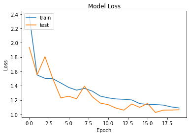

```python
train_data, test_data = data_reset(1/255.)

labels = get_labels(train_data)
predictions = ANN.predict(train_data)
print(classification_report(labels,backend.argmax(predictions).numpy()))

labels = get_labels(test_data)
predictions = ANN.predict(test_data)
print(classification_report(labels,backend.argmax(predictions).numpy()))

print_details(history,train_data,test_data)
```